# Eval Perception

Mathilde Bruguet

2023-11-22

## Tri hierarchique

```r
library(data.table)
library(FactoMineR)
library(tidyverse)
library(SensoMineR)
```

Etape préliminaire à l’AFM pour renseigner l’argument group . On créé le vecteur groupe qui renseigne le nombre de hierarchies par enfant. On récupère une chaine de charactère des noms des colonnes et on sépare En°enfant de Hn°hierarchie.

Ce qui correspond au nlevels de la vraibale X1 de la table e.

```r
trih <- fread("trih.txt")
rnames <- trih[,1]
trih <- trih[,2:430]

e <- strsplit(names(trih),".")
e <-data.frame(t(data.frame(strsplit(names(trih),"-"))))

e$X1 <- as.factor(e$X1)
nlevels(e$X1)
```

```
## [1] 170
```

```r
groupe = as.vector(summary(e[,1],175))


trih <- data.frame(trih)
trih <-trih[,sort(names(trih))]

for (i in 1:dim(trih)[2]) trih[,i] <- as.factor(trih[,i])
summary(trih)
```

[output not shown]

[output cut: 369 more lines]

[output not shown]

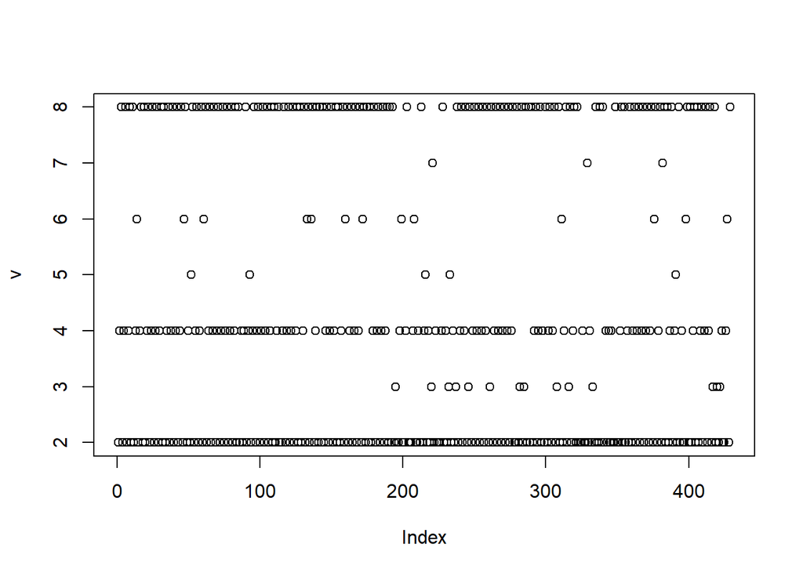

```r
v <- c()
for (i in 1: dim(trih)[2]) v <-append(v, nlevels(trih[,i]))## On vérifie qu'on a pas des données de tri  hierachiques
plot(v) ## On a pas de variables sans variabilité.
```

On réalise l’AFM en précisant les groupes qui correspondent au nombre de hiérachies réalisées par chaque enfant. On cherche les coordonnées d’un enfant qui a des coordonnées élevées sur la première dimension. On choisit l’enfant E80. Ensuite, on concatène les coordonnées des individus sur les 5 premières dimensions aux données du design expérimental dans la table d . Ensuite on réalise une ACP sur d avec l’argument scale.unit = FALSE, afin de prendre en compte les coordonnées des individus sur chaque dimension. Avec scale.unit = FALSE, On veut garder le fait que la dimension 1 apporte plus d’info que la dimension 2. On projette en supplémentaires les variables qualitatives correspondant au design expérimental pour comprendre comment les individus ont réalisé leurs hierarchies. Grâce aux éléments supplémentaire on peut interpréter les 2 premières dimensions de l’ACP: - dim 1 : rond/carré - dim 2 : grand/petit Si un enfant à des grandes coordonnées en dimension 1 ça veut dire qu’il a séparé en premier les ronds des carrés.

```r
res.MFA<-MFA(trih,
             group = groupe,
             type = rep("n",nlevels(e$X1)))
```

[figure not shown]

[figure not shown]

[figure not shown]

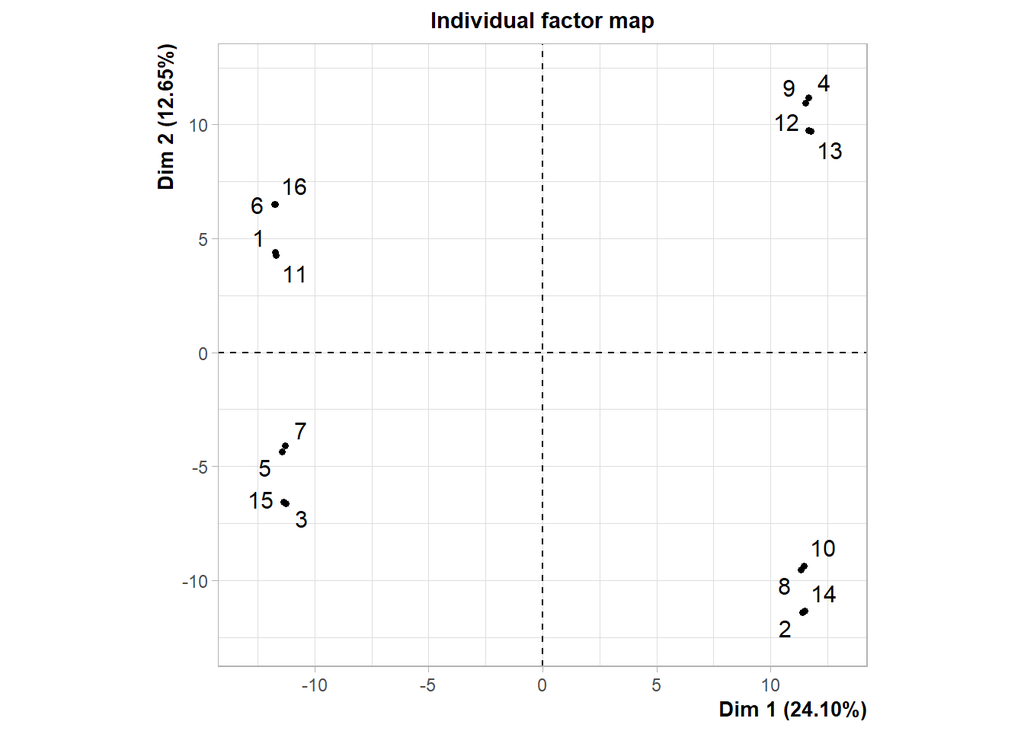

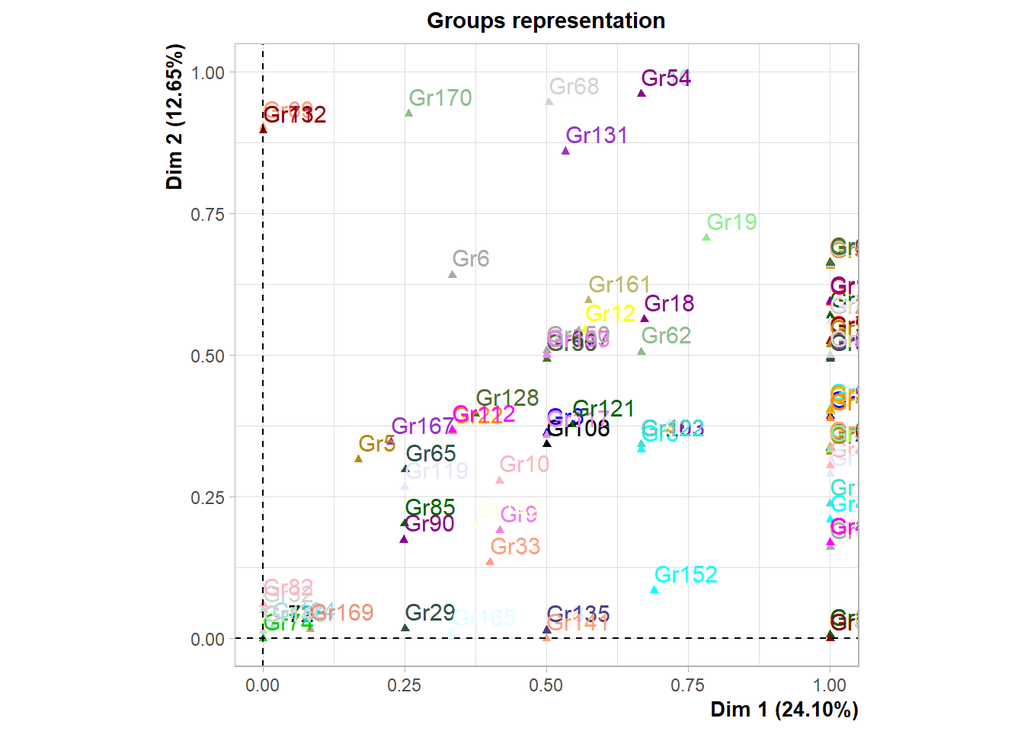

```r
res.MFA$groupe$coord ## recherche d'un enfant extrême
```

```r
enfant <- trih[,c("E80.H1","E80.H2")]# Partie correspondants au données récolté pour l'enfant E80
```

```r
## Contribution  et design

design <- readxl::read_excel("Design.xls") ## Données du design expérimentale
d <- cbind(res.MFA$ind$coord,design) # concaténation de toutes les coordonnées
#des individus sur les 5 ères dimensions avec des données design

rownames(d) <- d[,6] # On définit le nom des lignes par les stimulis
d <- d[,-6]## On enlève la colonne des stimulis


res.PCA <- PCA(d,quali.sup = c(6:12),scale.unit =FALSE)
```

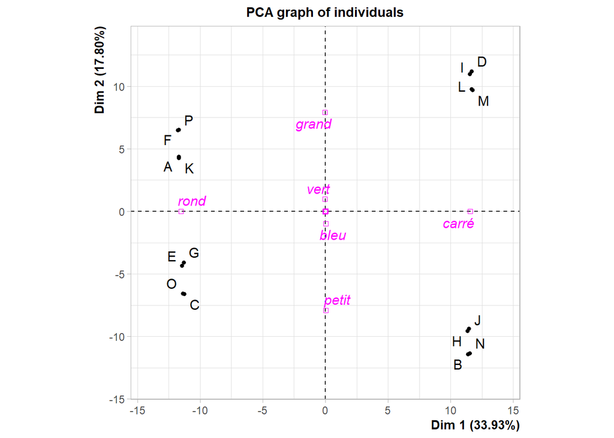

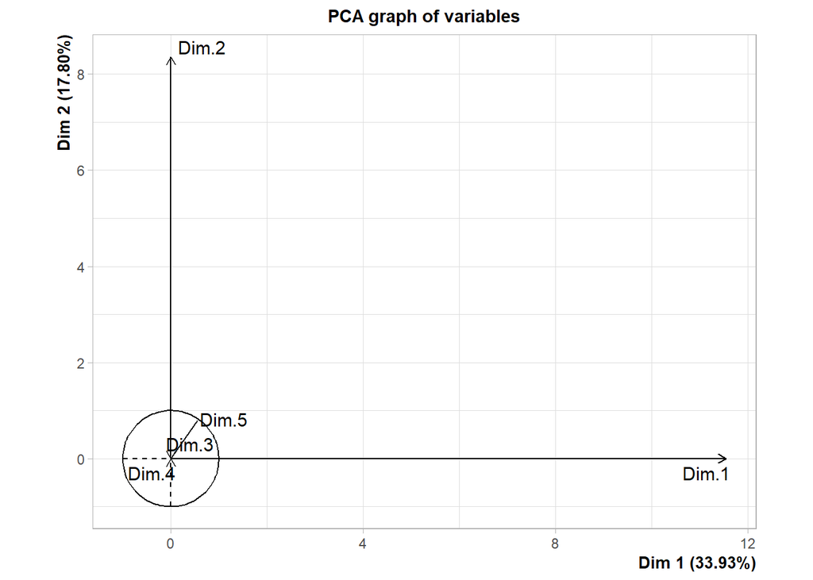

Dans “d” On récupère les coordonées des composantes principales de l’AFM auquel on ajoute le plan expérimentale de l’expérience (aka quels designs sont associés à chacune des cartes, donc à chacun des stimuli) On projette dans les coordonnées de l’AFM les designs, ce qui nous permet de voir les projections de ces derniers, voir comment ils sont répartis.

```r
d2 <- cbind(d,enfant)

res.PCA2 <- PCA(d2, quali.sup=c(6:14),scale.unit=FALSE )
```

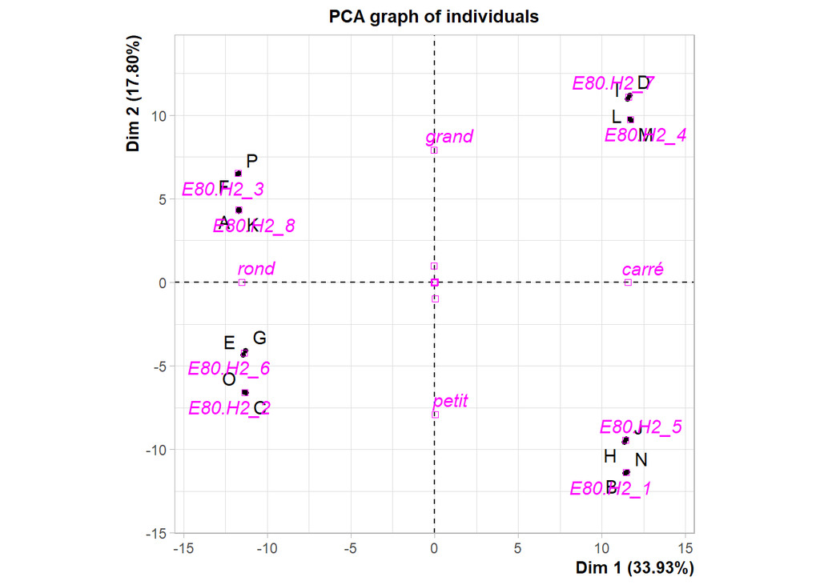

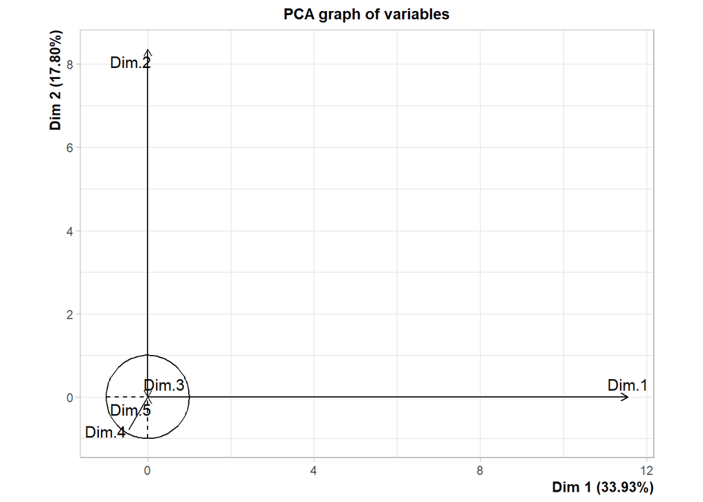

```r
## Autre solution
design_e1=cbind(design,trih[,"E80.H1"])
catdes(design_e1, num.var=8) ## Donne la clé de séparation à sa première hierachie
```

```
##
## Link between the cluster variable and the categorical variables (chi-square test)
## =================================================================================
##      p.value df
##
## Description of each cluster by the categories
## =============================================
## NULL
```

d2: On recrée une table où on ajoute les données de tri hierarchique de l’enfant “enfant”, à la table d contenant les coordonnées des individus de la 1er AFM et les données du design expérimental. => l’intéret de cette table est de représenter les étapes du raisonnement cognitif de l’enfant. En effet, on va projeter en supplémentaire les designs et les hiérarchies de l’enfant, ce qui va nous permettre, par la projection des hiérarchies de l’enfant, de comprendre les designs associés dans ses hiérarchies.

On fait une ACP où cette fois on ajoute en variable supplémentaire en plus du design les données de tri de l’enfant E80 et on regarde de quel design il est proche. Afin de voir quel “choix” l’enfant à réalisé lors de son tri.

Une autre solution , existe avec catdes, on peut déterminer la clé de spération mais pour une seule hierachie. La fonction “catdes” prend le design de chaque carte, une hiérarchie (ie une classification des cartes), et cela renvoie les modalités(ici les design) associés à chaque classe. décrit chaque classe en fonction des modalités du plan d’expérience.

```r
### Coordonnée des groupes
new.table <- data.frame(cbind(res.MFA$ind$coord,res.MFA$ind$coord,enfant,design[,-1]))


groupe2 = c(5,5, rep(1,9))
type2 = c("c","c", rep("n",9))

name_groupe <-c("GR1","GR2","H1","H2", names(design))
name_groupe <- name_groupe[-5]

res.MFA.E1 <- MFA(new.table, ncp = 5,
                  type = type2, group = groupe2 ,
                  num.group.sup = c(3:10), name.group= name_groupe)
```

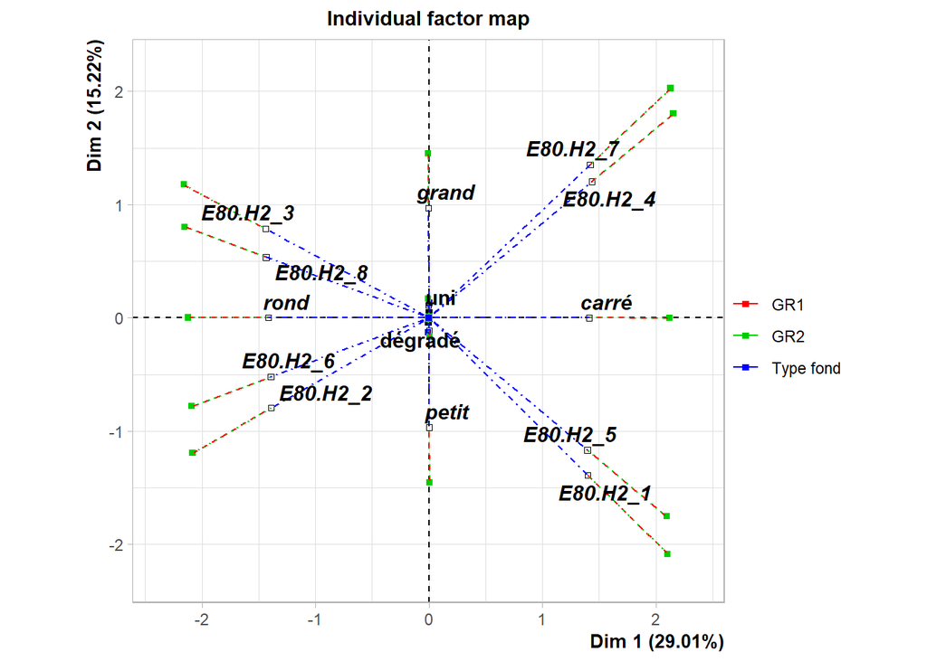

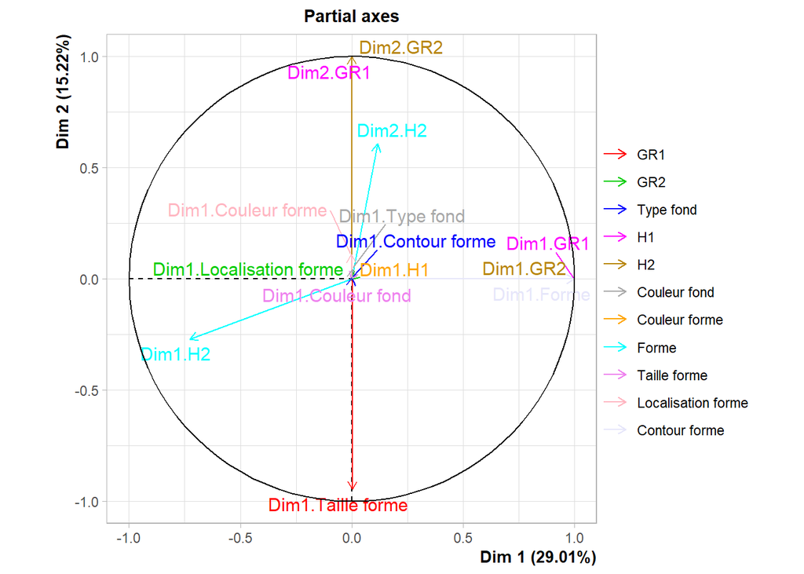

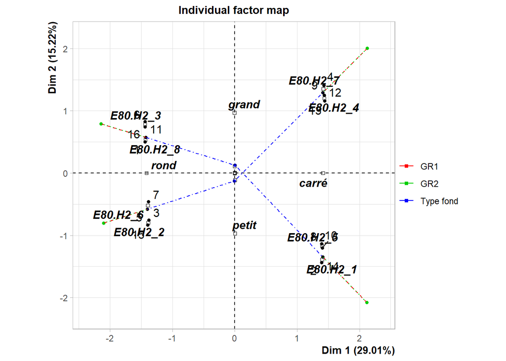

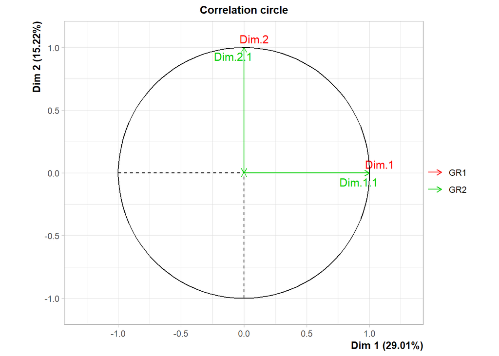

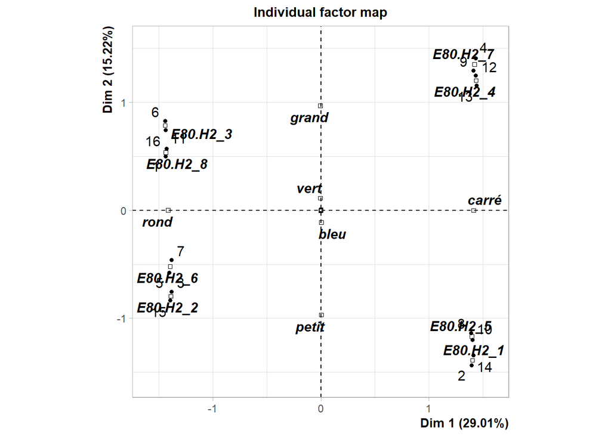

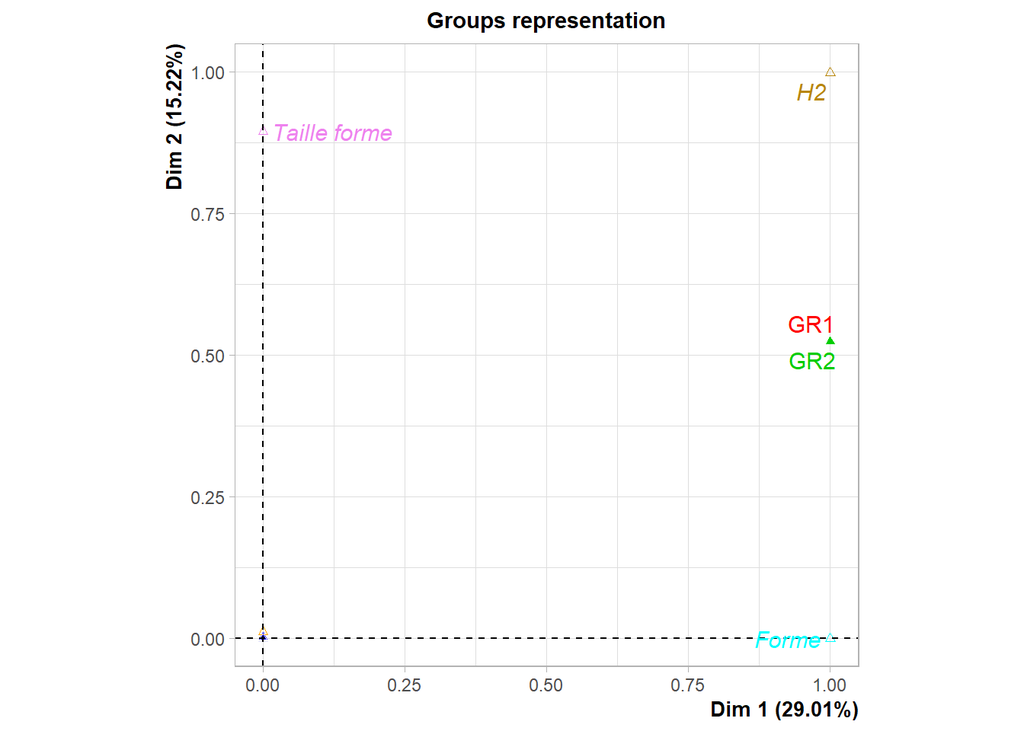

```r
#d_e <- cbind(design[,-6],enfant]
#catdes(d_e,num.var=8) # permet de caractériser les liens

# Différence entre % inertie entre Mathis et nous car il a pas pris les même
# dimension ( moi 5 et lui 2)


## Il ne reste qu'à faire la liaison entre les H1 et H2
```

On cherche à représenter les étapes du raisonnement cognitif de l’enfant lors de son tri. Pour celà on réalise une AFM, avec en élément supplémentaire , les hierachies de l’enfant E80 “H1” et “H2” et les designs.

On crée une table en dupliquant les coordonnées des individus , le tri de l’enfant 80 et les variables de design. Pour réaliser une AFM et visualiser dans le carré des liaisons les niveaux hierachiques 1 et 2 de l’enfant 80.

```r
## Maintenant on récupère le descriptif de la tâche de tri et on va regarder parmis les varibales ce
 # qui caracétrise vraiement la tâche de tri et ce qui caractérise les enfant


descript <- readxl::read_excel("Descriptive.xls", )

descript$Ind <- as.factor(descript$Ind)
descript$Jour <- as.factor(descript$Jour)
descript$Prénom <- as.factor(descript$Prénom)
descript$Symétrique <- as.factor(descript$Symétrique)
descript$classetemps <- as.factor(descript$classetemps)

descript$Age <- as.factor(descript$Age)
descript$Sexe <- as.factor(descript$Sexe)
descript$Juge <- as.factor(descript$Juge)
descript$Lunettes <- as.factor(descript$Lunettes)
descript$DroitierGaucher <- as.factor(descript$DroitierGaucher)

res.des<- PCA(descript[,1:16], quali.sup = c(1:3,8,10:16))
```

[figure not shown]

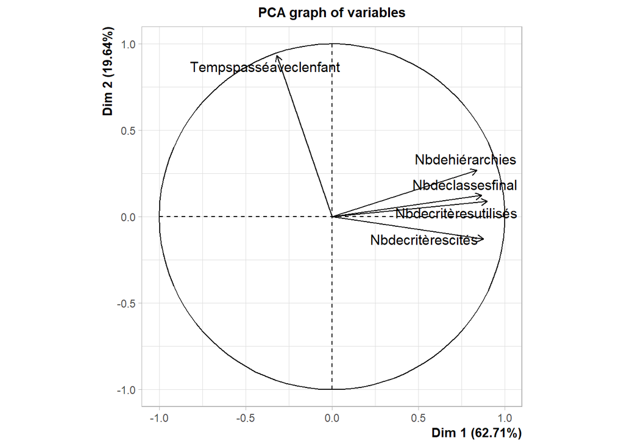

```r
res.des<- PCA(descript[,c(4:7,9,11)], quali.sup = c(6))
```

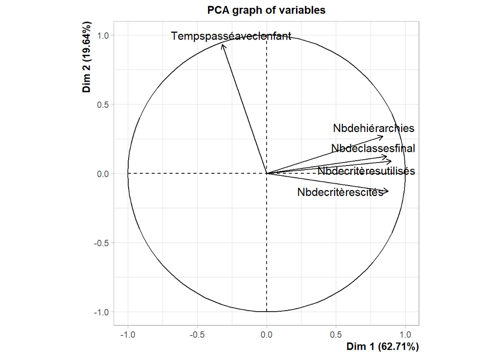

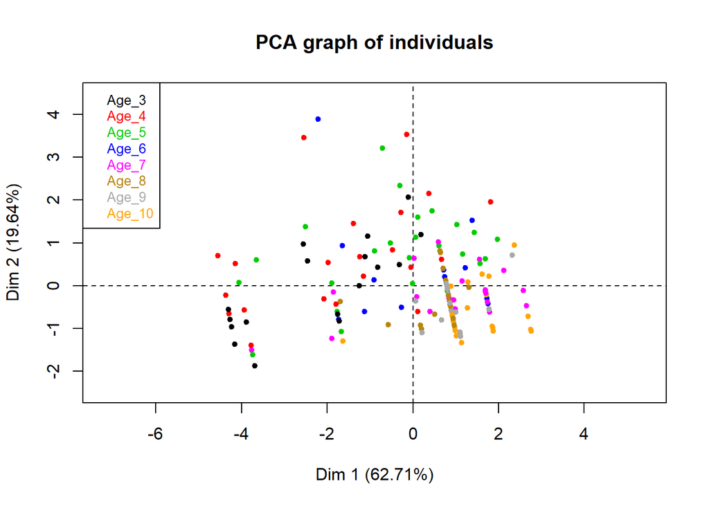

```r
plot.PCA(res.des, habillage = 6, graph.type = "classic", invisible = "quali", label="none")
```

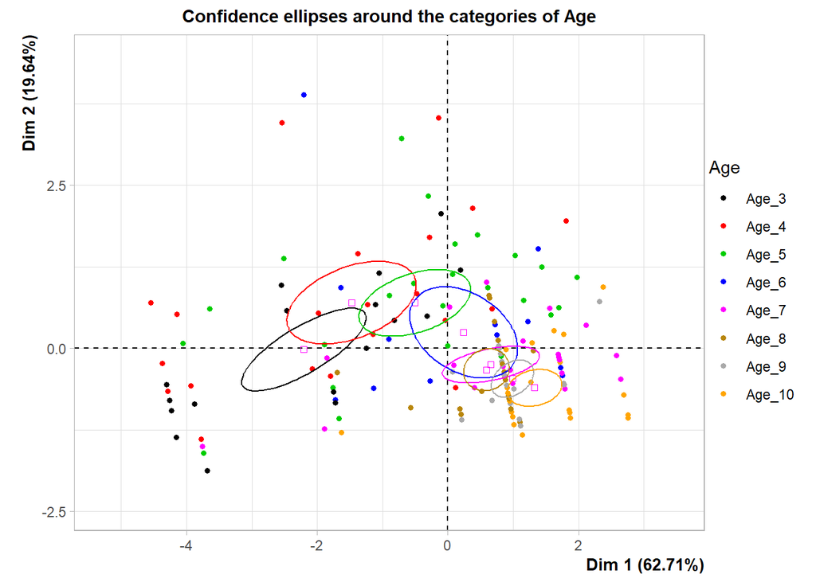

```r
plotellipses(res.des,label ="none")
```

On observe un gradient au niveau des ellipses , on voit que la variabilité des tris diminue plus l’âge des enfants augmentent.